# Week 06 — Variants

Author

Abby Farr

Published

November 10, 2026

## 1. This week’s analysis

# Download VCF

```r
dir.create("data/week06", recursive = TRUE, showWarnings = FALSE)
dir.create("output/week06", recursive = TRUE, showWarnings = FALSE)

base <- "https://raw.githubusercontent.com/course-fish546-2026/Roberts-546/main"
download.file(paste0(base, "/output/04-stacks-demo/populations/populations.snps.vcf"),
              "data/week06/eelgrass-demo.vcf")
download.file(paste0(base, "/data/stacks-demo/popmap.tsv"),
              "data/week06/popmap.tsv")
```

# Read header

```r
lines  <- readLines("data/week06/eelgrass-demo.vcf")
header <- lines[startsWith(lines, "##")] # Lines starting with ## describe the file: the program that made it, and what each INFO and FORMAT field means.
header
```

```
 [1] "##fileformat=VCFv4.2"
 [2] "##fileDate=20261017"
 [3] "##source=\"Stacks v2.68\""
 [4] "##INFO=<ID=AD,Number=R,Type=Integer,Description=\"Total Depth for Each Allele\">"
 [5] "##INFO=<ID=AF,Number=A,Type=Float,Description=\"Allele Frequency\">"
 [6] "##INFO=<ID=DP,Number=1,Type=Integer,Description=\"Total Depth\">"
 [7] "##INFO=<ID=NS,Number=1,Type=Integer,Description=\"Number of Samples With Data\">"
 [8] "##FORMAT=<ID=AD,Number=R,Type=Integer,Description=\"Allele Depth\">"
 [9] "##FORMAT=<ID=DP,Number=1,Type=Integer,Description=\"Read Depth\">"
[10] "##FORMAT=<ID=HQ,Number=2,Type=Integer,Description=\"Haplotype Quality\">"
[11] "##FORMAT=<ID=GL,Number=G,Type=Float,Description=\"Genotype Likelihood\">"
[12] "##FORMAT=<ID=GQ,Number=1,Type=Integer,Description=\"Genotype Quality\">"
[13] "##FORMAT=<ID=GT,Number=1,Type=String,Description=\"Genotype\">"
[14] "##INFO=<ID=loc_strand,Number=1,Type=Character,Description=\"Genomic strand the corresponding Stacks locus aligns on\">"
```

# Read variant table

```r
vcf <- read.delim("data/week06/eelgrass-demo.vcf", comment.char = "",
                  skip = length(header), check.names = FALSE)
names(vcf)[1] <- "CHROM"   # was "#CHROM"
dim(vcf)                   # 213 SNPs; 9 fixed columns + 20 samples
```

```
[1] 213  29
```

```r
vcf[1:3, 1:10]
```

```
  CHROM POS   ID REF ALT QUAL FILTER           INFO         FORMAT
1     1  47 1:46   G   T    .   PASS NS=18;AF=0.278 GT:DP:AD:GQ:GL
2     2  67 2:66   A   G    .   PASS NS=19;AF=0.316 GT:DP:AD:GQ:GL
3     5  70 5:69   A   C    .   PASS NS=20;AF=0.300 GT:DP:AD:GQ:GL
                               PB_01
1   0/1:15:9,6:40:-18.29,0.00,-30.37
2 0/1:30:15,15:40:-48.49,0.00,-49.03
3  0/0:24:24,0:40:-0.00,-7.45,-94.51
```

```r
samples <- names(vcf)[10:ncol(vcf)]
popmap  <- read.delim("data/week06/popmap.tsv", header = FALSE, col.names = c("sample", "pop"))
stopifnot(all(popmap$sample == samples))
```

# Pull our genotypes and depth

```r
gt <- sapply(vcf[, samples], function(x) sub(":.*", "", x))
# Missing genotypes ("./.") have no depth, so they become NA
dp <- suppressWarnings(sapply(vcf[, samples],
                              function(x) as.numeric(sub("^[^:]*:([^:]*):.*", "\\1", x))))
rownames(gt) <- rownames(dp) <- vcf$ID
table(gt)
```

```
gt
 ./.  0/0  0/1  1/1
 239 1987 1545  489
```

```r
# Count ALT alleles per genotype: 0, 1, or 2
alt <- apply(gt, 2, function(g) c("0/0" = 0, "0/1" = 1, "1/1" = 2)[g])
rownames(alt) <- vcf$ID

colSums(is.na(alt))   # missing genotypes per sample
```

```
PB_01 PB_02 PB_03 PB_04 PB_05 PB_06 PB_07 PB_08 PB_09 PB_10 SJ_01 SJ_02 SJ_03
    6    10    13     8    12    12    18    13    10    13     9    10    16
SJ_04 SJ_05 SJ_06 SJ_07 SJ_08 SJ_09 SJ_10
    6    13    13    19    16    15     7
```

# Summerize each SNP

```r
snps <- data.frame(
  id         = vcf$ID,
  locus      = vcf$CHROM,
  pos        = vcf$POS,
  n_called   = rowSums(!is.na(alt)),
  mean_depth = rowMeans(dp, na.rm = TRUE),
  alt_freq   = rowSums(alt, na.rm = TRUE) / (2 * rowSums(!is.na(alt)))
)
snps$maf <- pmin(snps$alt_freq, 1 - snps$alt_freq)   # minor allele frequency
summary(snps)
```

```
      id                locus            pos           n_called
 Length:213         Min.   :  1.0   Min.   :12.00   Min.   :16.00
 Class :character   1st Qu.: 83.0   1st Qu.:33.00   1st Qu.:18.00
 Mode  :character   Median :152.0   Median :51.00   Median :19.00
                    Mean   :152.2   Mean   :50.09   Mean   :18.88
                    3rd Qu.:225.0   3rd Qu.:69.00   3rd Qu.:20.00
                    Max.   :299.0   Max.   :89.00   Max.   :20.00
   mean_depth       alt_freq           maf
 Min.   :16.15   Min.   :0.0500   Min.   :0.0500
 1st Qu.:18.40   1st Qu.:0.2105   1st Qu.:0.2105
 Median :19.37   Median :0.3250   Median :0.3250
 Mean   :19.40   Mean   :0.3135   Mean   :0.3135
 3rd Qu.:20.37   3rd Qu.:0.4250   3rd Qu.:0.4250
 Max.   :23.15   Max.   :0.5000   Max.   :0.5000
```

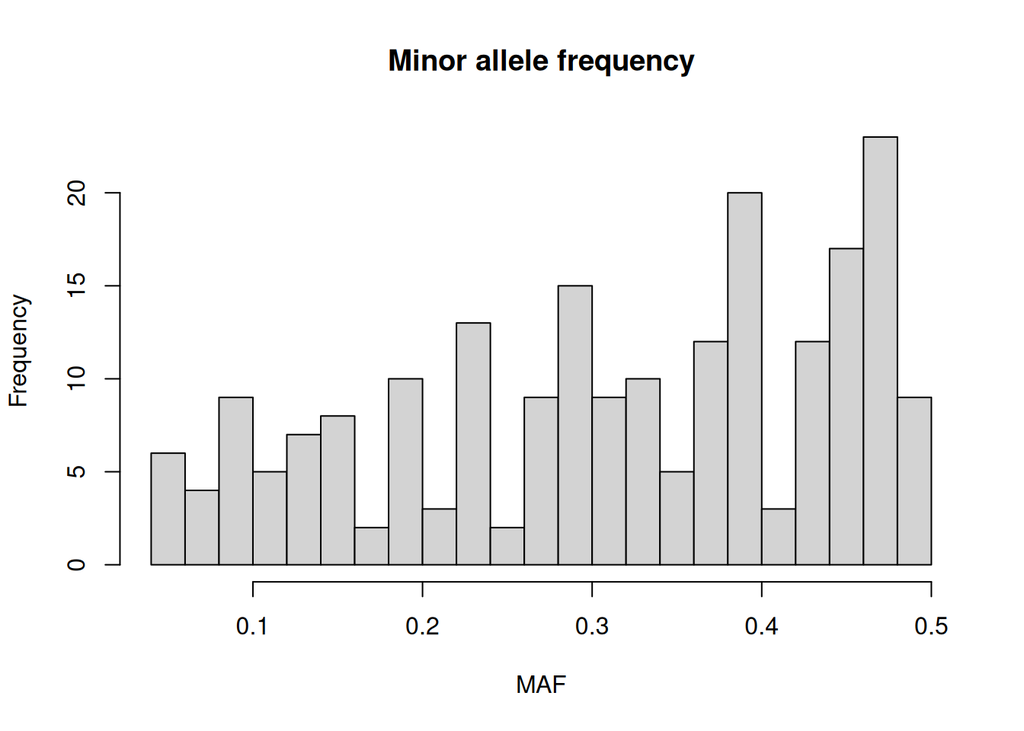

```r
hist(snps$maf, breaks = 20, main = "Minor allele frequency", xlab = "MAF")
```

# Filter and count before and after

```r
keep <- snps$n_called >= 18 & snps$maf >= 0.05
nrow(snps)   # before
```

```
[1] 213
```

```r
sum(keep)    # after
```

```
[1] 194
```

```r
table(called_18 = snps$n_called >= 18, maf_05 = snps$maf >= 0.15)
```

```
         maf_05
called_18 FALSE TRUE
    FALSE     6   13
    TRUE     27  167
```

# Compare two sites

```r
filtered <- snps[keep, ]
is_pb <- popmap$pop == "PB"
af <- function(a) rowSums(a, na.rm = TRUE) / (2 * rowSums(!is.na(a)))

filtered$freq_PB   <- af(alt[keep, is_pb])
filtered$freq_SJ   <- af(alt[keep, !is_pb])
filtered$freq_diff <- abs(filtered$freq_PB - filtered$freq_SJ)
filtered <- filtered[order(-filtered$freq_diff), ]
head(filtered, 10)
```

```
           id locus pos n_called mean_depth  alt_freq       maf    freq_PB
158:17 158:17   158  18       19   18.47368 0.4736842 0.4736842 1.00000000
17:43   17:43    17  44       19   18.21053 0.4736842 0.4736842 0.90000000
178:71 178:71   178  72       19   18.52632 0.4736842 0.4736842 0.00000000
246:68 246:68   246  69       18   19.61111 0.5000000 0.5000000 0.90000000
139:70 139:70   139  71       20   18.90000 0.5000000 0.5000000 0.95000000
141:14 141:14   141  15       19   17.52632 0.4736842 0.4736842 0.94444444
119:87 119:87   119  88       20   19.10000 0.4250000 0.4250000 0.85000000
31:86   31:86    31  87       19   19.63158 0.5000000 0.5000000 0.05555556
159:50 159:50   159  51       19   18.00000 0.5000000 0.5000000 0.10000000
87:63   87:63    87  64       20   19.70000 0.5000000 0.5000000 0.10000000
         freq_SJ freq_diff
158:17 0.0000000 1.0000000
17:43  0.0000000 0.9000000
178:71 0.9000000 0.9000000
246:68 0.0000000 0.9000000
139:70 0.0500000 0.9000000
141:14 0.0500000 0.8944444
119:87 0.0000000 0.8500000
31:86  0.9000000 0.8444444
159:50 0.9444444 0.8444444
87:63  0.9000000 0.8000000
```

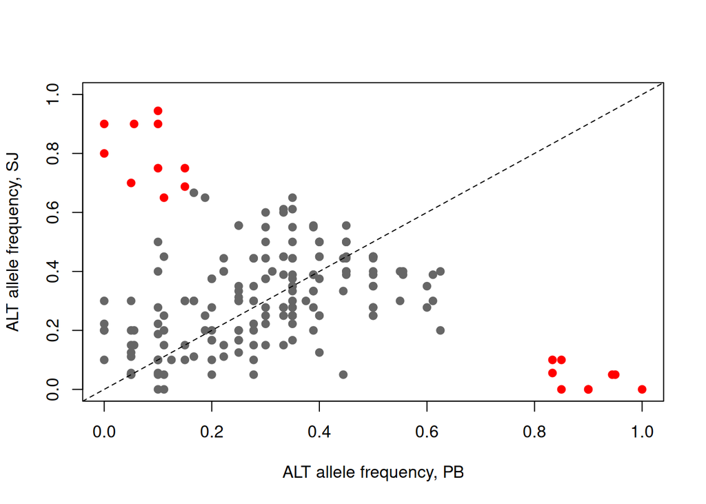

```r
plot(filtered$freq_PB, filtered$freq_SJ, xlim = c(0, 1), ylim = c(0, 1),
     xlab = "ALT allele frequency, PB", ylab = "ALT allele frequency, SJ",
     pch = 19, col = ifelse(filtered$freq_diff > 0.5, "red", "grey40"))
abline(0, 1, lty = 2)   # SNPs on this line have the same frequency at both sites
```

```r
write.csv(filtered, "output/week06/snp-summary-filtered.csv", row.names = FALSE)
sum(filtered$freq_diff > 0.5)
```

```
[1] 19
```

# What to write

1. What the INFO and FORMAT fields in this VCF contain. This file has no QUAL score (.). What does that mean for filtering?

> Before filtering I had 213 counts and after filtering I had 194 counts. The minor allele frequency filter did not remove any counts becuase the minimum MAF was 0.05 which means when we filtered for anything 0.05 and above all counts met that threshold.
3. Change one threshold (for example n_called >= 20, or maf >= 0.2) and report how the counts and the number of strongly different SNPs change.

## 2. Reflection questions

1. What does a variant call represent?

> A variant call represents a file that stores gene sequence variations and identifies changes in sequenced genome compared to the reference genome.
2. How can read depth, genotype quality, or filtering thresholds change a biological interpretation?

> These three things can change a biological interpretation because depending on where you put the threshold for filtering or how good the reads are you could be losing data that is important for the confidence in identification or inversly you could be allowing bad reads to be in the data giving false confidence in species identification.
3. What is your strongest current project output, and what is the riskiest step remaining?

> The strongest output I currently have for my project is a bar graph with percent of species at each site. The riskiest step remaining is turning that infomration into a diversity index for each site.

## 3. Project progress

> I have not done any work this week, I started looking into doing an annotation but since we do not do that I am moving on.

## 4. Where I’m stuck

> na

## 5. Next week

> This week I want to look at what species are present at the sites.